# Introduction to Images

Author

Jasper Day

Published

June 6, 2022

# 1 What is an image?

On a computer, an image is a grid of coloured squares. You index into the array from the upper left hand corner.

You can download images from online using `download(url, "filename")`.

First we load the dependencies:

```julia
using Images
```

Then we can start loading images.

```julia
url = "https://i.imgur.com/VGPeJ6s.jpg"
download(url, "./philip.jpg")
```

```
"./philip.jpg"
```

[figure not shown]

Figure 1: Here’s the image we just downloaded

And here’s the image loaded into a Julia variable:

```julia
philip = load("./philip.jpg")
@show typeof(philip)
@show size(philip)
# Philip is an array of these RGBX objects.
RGBX(0.1,0.9,0.2)
```

```
typeof(philip) = Matrix{RGB{N0f8}}
```

```
size(philip) = (3675, 2988)
```

[figure not shown]

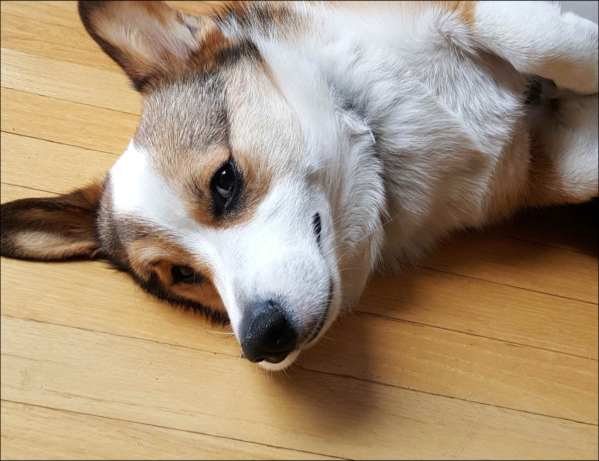

```julia
(h,w) = size(philip)
head = philip[(h ÷ 2):h, (w ÷ 10): (9w ÷ 10)]
```

You can also concatenate arrays:

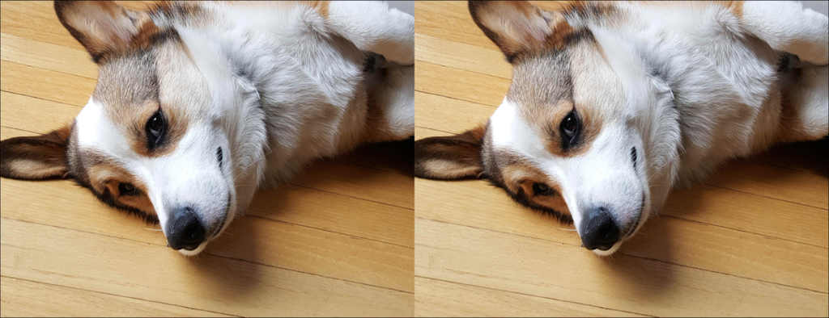

```julia
[head head]
```

You could create a kaleidoscopic corgi: (`dims` is which dimension to reverse along.)

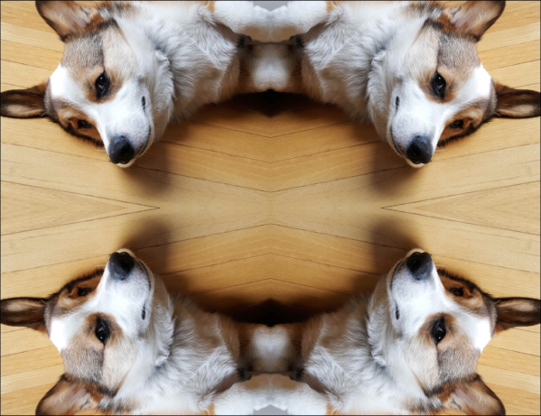

```julia
[
    head                    reverse(head, dims=2)
    reverse(head, dims=1)   reverse(reverse(head, dims=1), dims=2)
]
```

# 2 Image manipulation:

There are two ways to get in an image and change it:

- **Modify** the numbers inside the array (mutations): this is useful to change a small piece of the array
- Create a new **copy** of the array: this is useful to alter everything together. Use `copy()`.

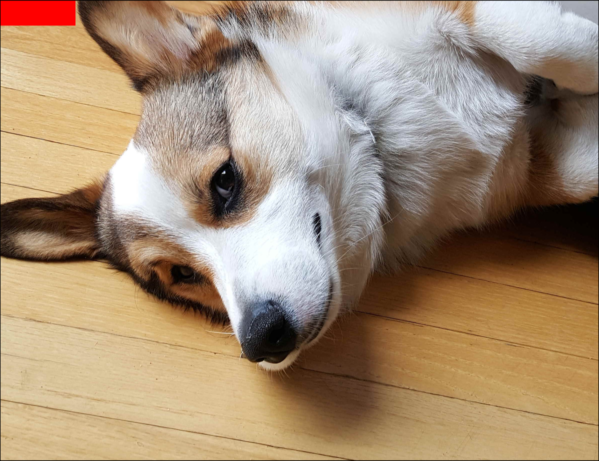

```julia
new_phil = copy(head)
new_phil[1:100, 1:300] .= RGBX(1,0,0)
# You could also do this with two nested "for" loops.
display(new_phil)
```

The above is an example of **broadcasting**, which allows element-wise operation of various functions on the elements of arrays.

You can broadcast with functions:

```julia
function redify(color)
    return RGB(color.r, 0, 0)
end
```

```
redify (generic function with 1 method)
```

The function `redify` pulls out only the red portion of the given color. We can use the dot operator `.` to apply our new function to every element of an array.

```julia
redify.(head)
# "Dot" operator applies redify across every element of philip
```

[figure not shown]

To get our start with image manipulation, let’s write a function to compress images:

(see Grant’s far better implementation of the function here)

```julia
function decimate(array, elements)
    (x, y) = size(array)
    new_array = copy(array[range(start=1,step=elements,stop=x),range(start=1,step=elements,stop=y)])
    return new_array
end
```

```
decimate (generic function with 1 method)
```

Let’s **decimate** poor Phil:

```
size(new_phil) = (1839, 2392)
```

```
size(poor_phil) = (368, 479)
```

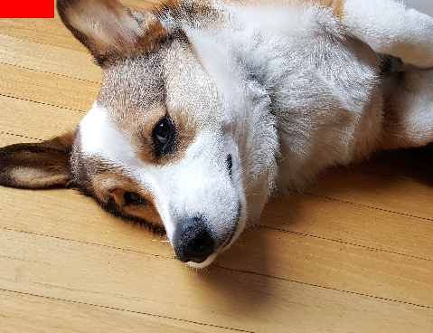

```julia
@show size(new_phil)
poor_phil = decimate(new_phil, 5)
@show size(poor_phil)
display(poor_phil)
```

As you can see, we’ve reduced the size of Phil by a factor of 5.